# Implementação do Plano Amostral da Pesquisa Nacional de Saúde no R: um estudo de caso sobre a asma no Brasil

**Ingo Dube Souza**

Programa de Pós Graduação em Estatística e Ciência de Dados (PGECD/UFBA)

Estudos Econômicos (SENAI/CIMATEC)

ingo.dube@ufba.br

**Maria Eduarda de Lima e Silva**

Dra. em Economia Aplicada (UFRGS)

Estudos Econômicos (SENAI/CIMATEC)

Relatório metodológico

Relatório técnico dos estimadores, intervalos de confiança, indicadores epidemiológicos e interpretação dos resultados da PNS 2013-2019 no contexto da asma.

19/10/2026

[Repositório do projeto](https://github.com/ingodube/PNS_2013_2019)

**Palavras-chave:** Pesquisa Nacional de Saúde; Plano amostral; Asma

**Sumário**

# 1 Introdução

A PNS permite estimar a frequência de diagnóstico de asma e descrever algumas experiências de cuidado na população adulta. Essas informações dependem tanto do desenho amostral quanto das perguntas recebidas pelos participantes. Este relatório documenta os indicadores, seus denominadores e os limites da comparação entre 2013 e 2019.

O diagnóstico investigado é autorreferido e se refere a alguma ocasião da vida. Pode refletir ocorrência de doença e acesso ao diagnóstico, mas não identifica isoladamente asma ativa, necessidade atual de tratamento ou utilização anual de serviços (Menezes et al., 2015).

## 1.1 Nota de revisão metodológica

Esta versão substitui os resultados anteriores após reprocessamento dos microdados. Foram corrigidos o domínio etário, os fluxos de elegibilidade, a classificação de causas e o tratamento da renda. Os resultados anteriores do documento Word não foram utilizados. A validação inclui recodificação, pesos, estimadores e concordância dos produtos bilíngues. O histórico e os arquivos de execução estão disponíveis no repositório.

# 2 Fonte dos dados e escopo analítico

São utilizados microdados oficiais da PNS 2013 e 2019, inquéritos transversais repetidos sem seguimento individual nesta análise. O morador selecionado tinha ≥18 anos em 2013 e ≥15 anos em 2019. Todos os resultados deste relatório utilizam o domínio comum ≥18 anos. Não foi realizada padronização por idade ou sexo.

A importação usa `labels = FALSE`, preservando códigos oficiais. Os dados de origem ficam em cache fora do Git. O manifesto registra arquivos, hashes, versões e verificações do desenho. A renderização lê resultados calculados previamente.

# 3 Implementação do plano amostral complexo

O desenho é construído para todos os moradores selecionados antes da definição dos domínios. Usa `UPA_PNS`, `V0024` e o peso inicial `V0029`, seguido de pós-estratificação por `V00293` com os totais `V00292`. Cada domínio é associado explicitamente ao seu total. Os pesos resultantes são confrontados com `V00291`, com tolerância relativa de 10⁻⁶ pela precisão dos arquivos; os totais devem ser recuperados com erro relativo inferior a 10⁻¹⁰.

O objeto representa estratos e conglomerados disponíveis para estimação da variância; não reconstrói explicitamente cada estágio ou fração amostral. Restrições de idade, diagnóstico e território são operações de domínio (Souza-Júnior et al., 2015; Lumley, 2010).

`survey.lonely.psu = "adjust"` trata estratos com uma única UPA. A opção adicional para domínios solitários não garante ajuste em desenhos pós-estratificados. As saídas incluem número de UPAs, estratos, graus de liberdade, estratos com apenas uma UPA no domínio (`lonely_strata_n`) e condição de estimabilidade. Essa contagem sinaliza uma limitação de precisão; a existência de um IC calculável não elimina a limitação.

Verificações do desenho

| Ano | Selecionados | Adultos | Menores de 18 | Idade inválida |
| --- | --- | --- | --- | --- |
| 2013 | 60202 | 60202 | 0 | 0 |
| 2019 | 90846 | 88531 | 2315 | 0 |

Fonte: cálculos dos autores com microdados oficiais da PNS.

# 4 Estimadores e intervalos de confiança

Proporções e médias são razões entre somas ponderadas, calculadas entre respondentes elegíveis com informação válida. Ignorado, elegibilidade desconhecida e pergunta não aplicável são distinguidos na recodificação. A coluna de ausentes nas tabelas é a porcentagem ponderada de informação inválida dentro do domínio elegível. Respostas ausentes nas perguntas anteriores podem impedir a identificação da elegibilidade.

As proporções usam `svymean()` para estimativa e erro-padrão e `svyciprop(method = "beta")` para o IC de 95% (Korn e Graubard, 1998). As médias usam aproximação t com graus de liberdade do domínio. Proporções observadas iguais a zero ou um são apresentadas com IC não estimável; domínios vazios e variâncias indisponíveis têm estados explícitos.

As diferenças de diagnóstico, crises e tabagismo são expressas em pontos percentuais. O erro-padrão combina as variâncias das edições sob aproximação de independência; o IC usa graus de liberdade de Welch–Satterthwaite. A covariância entre edições não é estimada. Contrastes nacionais são prioritários; os estaduais são exploratórios, sem interpretação confirmatória. Sobreposição de ICs individuais não testa diferença ou equivalência.

$$\widehat{\theta}_D = \frac{\sum_{i \in D} w_i y_i}{\sum_{i \in D} w_i}, \qquad SE(\widehat{\Delta}) = \sqrt{\widehat{V}_{2019}+\widehat{V}_{2013}}.$$

# 5 Indicadores de asma e contexto

## 5.1 Diagnóstico médico autorreferido

Numerador: resposta afirmativa a `Q074`. Denominador: adultos com resposta válida. O diagnóstico ao longo da vida pode ser afetado pela composição da população e pelo acesso ao diagnóstico.

2013: 4,41% [4,13%; 4,71%]; n = 60202. 2019: 5,27% [5,00%; 5,55%]; n = 88531.

Diagnóstico médico autorreferido

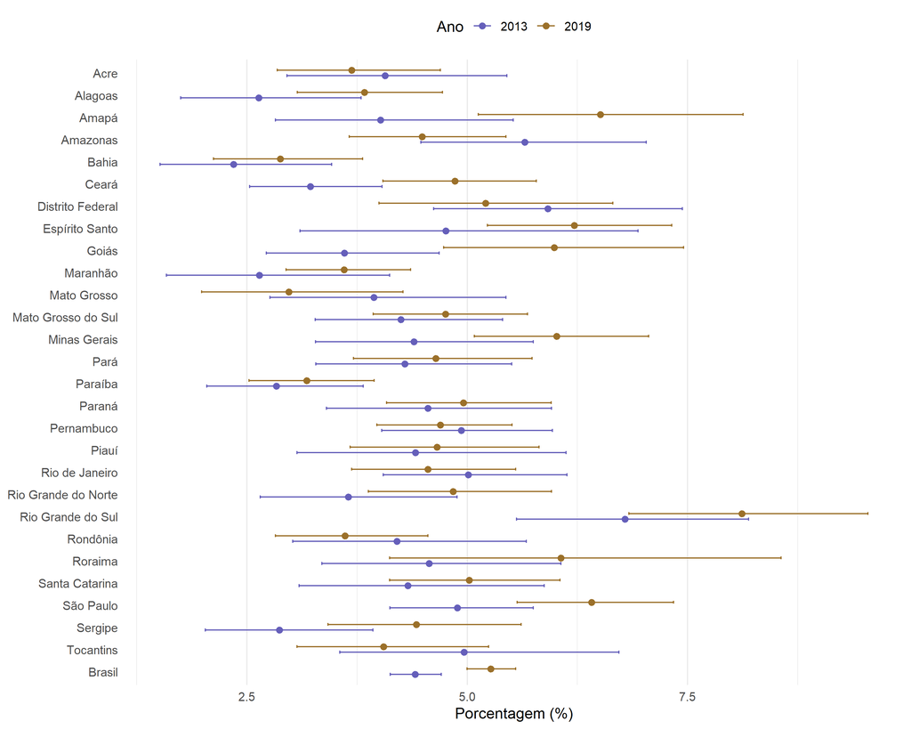

Diagnóstico médico autorreferido

| UF | Ano | Estimativa [IC 95%] | n válido | Ausentes (%) |
| --- | --- | --- | --- | --- |
| Acre | 2013 | 4,07% [2,95%; 5,45%] | 1814 | 0,00 |
| Acre | 2019 | 3,69% [2,84%; 4,69%] | 2283 | 0,00 |
| Alagoas | 2013 | 2,63% [1,75%; 3,79%] | 1748 | 0,00 |
| Alagoas | 2019 | 3,83% [3,07%; 4,72%] | 2898 | 0,00 |
| Amapá | 2013 | 4,02% [2,82%; 5,52%] | 1332 | 0,00 |
| Amapá | 2019 | 6,51% [5,13%; 8,13%] | 1473 | 0,00 |
| Amazonas | 2013 | 5,65% [4,47%; 7,03%] | 2586 | 0,00 |
| Amazonas | 2019 | 4,49% [3,66%; 5,44%] | 3370 | 0,00 |
| Bahia | 2013 | 2,35% [1,51%; 3,46%] | 2641 | 0,00 |
| Bahia | 2019 | 2,88% [2,12%; 3,81%] | 3600 | 0,00 |
| Ceará | 2013 | 3,22% [2,53%; 4,03%] | 2560 | 0,00 |
| Ceará | 2019 | 4,86% [4,04%; 5,78%] | 4141 | 0,00 |
| Distrito Federal | 2013 | 5,91% [4,62%; 7,44%] | 1811 | 0,00 |
| Distrito Federal | 2019 | 5,21% [4,00%; 6,65%] | 2305 | 0,00 |
| Espírito Santo | 2013 | 4,76% [3,10%; 6,94%] | 1724 | 0,00 |
| Espírito Santo | 2019 | 6,21% [5,23%; 7,32%] | 3463 | 0,00 |
| Goiás | 2013 | 3,61% [2,72%; 4,68%] | 2423 | 0,00 |
| Goiás | 2019 | 5,99% [4,73%; 7,45%] | 2648 | 0,00 |
| Maranhão | 2013 | 2,64% [1,59%; 4,12%] | 1774 | 0,00 |
| Maranhão | 2019 | 3,60% [2,94%; 4,36%] | 4889 | 0,00 |
| Mato Grosso | 2013 | 3,94% [2,76%; 5,44%] | 1476 | 0,00 |
| Mato Grosso | 2019 | 2,97% [1,98%; 4,27%] | 2423 | 0,00 |
| Mato Grosso do Sul | 2013 | 4,24% [3,28%; 5,40%] | 1809 | 0,00 |
| Mato Grosso do Sul | 2019 | 4,75% [3,93%; 5,68%] | 2805 | 0,00 |
| Minas Gerais | 2013 | 4,39% [3,28%; 5,75%] | 3779 | 0,00 |
| Minas Gerais | 2019 | 6,01% [5,08%; 7,06%] | 5128 | 0,00 |
| Pará | 2013 | 4,29% [3,28%; 5,50%] | 2004 | 0,00 |
| Pará | 2019 | 4,64% [3,71%; 5,74%] | 3696 | 0,00 |
| Paraíba | 2013 | 2,83% [2,05%; 3,82%] | 1943 | 0,00 |
| Paraíba | 2019 | 3,18% [2,52%; 3,94%] | 3068 | 0,00 |
| Paraná | 2013 | 4,55% [3,40%; 5,96%] | 3012 | 0,00 |
| Paraná | 2019 | 4,96% [4,09%; 5,95%] | 3893 | 0,00 |
| Pernambuco | 2013 | 4,93% [4,03%; 5,97%] | 2591 | 0,00 |
| Pernambuco | 2019 | 4,70% [3,97%; 5,51%] | 3992 | 0,00 |
| Piauí | 2013 | 4,41% [3,07%; 6,12%] | 1804 | 0,00 |
| Piauí | 2019 | 4,66% [3,67%; 5,82%] | 2674 | 0,00 |
| Rio de Janeiro | 2013 | 5,01% [4,04%; 6,13%] | 3486 | 0,00 |
| Rio de Janeiro | 2019 | 4,55% [3,69%; 5,55%] | 4849 | 0,00 |
| Rio Grande do Norte | 2013 | 3,65% [2,65%; 4,88%] | 1691 | 0,00 |
| Rio Grande do Norte | 2019 | 4,84% [3,88%; 5,95%] | 2877 | 0,00 |
| Rio Grande do Sul | 2013 | 6,79% [5,56%; 8,19%] | 2913 | 0,00 |
| Rio Grande do Sul | 2019 | 8,11% [6,84%; 9,55%] | 3707 | 0,00 |
| Rondônia | 2013 | 4,20% [3,02%; 5,67%] | 1694 | 0,00 |
| Rondônia | 2019 | 3,61% [2,82%; 4,55%] | 2108 | 0,00 |
| Roraima | 2013 | 4,57% [3,35%; 6,06%] | 1591 | 0,00 |
| Roraima | 2019 | 6,06% [4,12%; 8,56%] | 2135 | 0,00 |
| Santa Catarina | 2013 | 4,33% [3,09%; 5,87%] | 1623 | 0,00 |
| Santa Catarina | 2019 | 5,02% [4,12%; 6,05%] | 3676 | 0,00 |
| São Paulo | 2013 | 4,89% [4,12%; 5,75%] | 5305 | 0,00 |
| São Paulo | 2019 | 6,41% [5,57%; 7,34%] | 5995 | 0,00 |
| Sergipe | 2013 | 2,87% [2,03%; 3,93%] | 1553 | 0,00 |
| Sergipe | 2019 | 4,42% [3,42%; 5,61%] | 2563 | 0,00 |
| Tocantins | 2013 | 4,96% [3,55%; 6,72%] | 1515 | 0,00 |
| Tocantins | 2019 | 4,05% [3,07%; 5,24%] | 1872 | 0,00 |
| Brasil | 2013 | 4,41% [4,13%; 4,71%] | 60202 | 0,00 |
| Brasil | 2019 | 5,27% [5,00%; 5,55%] | 88531 | 0,00 |

Fonte: cálculos dos autores com microdados oficiais da PNS.

## 5.2 Crises nos últimos 12 meses

Numerador: resposta afirmativa a `Q076`. Denominador: adultos com diagnóstico e resposta válida sobre crise.

2013: 38,29% [34,93%; 41,73%]; n = 2620. 2019: 37,64% [35,04%; 40,29%]; n = 4294.

Crises nos últimos 12 meses

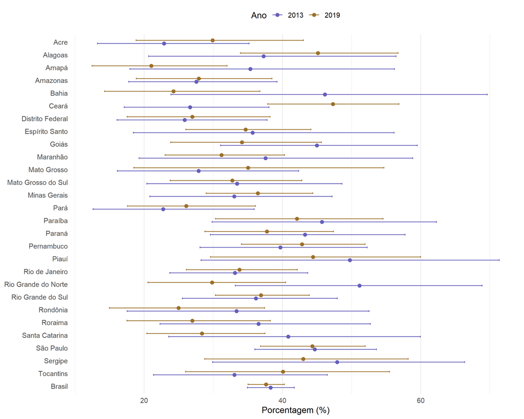

Crises nos últimos 12 meses

| UF | Ano | Estimativa [IC 95%] | n válido | Ausentes (%) |
| --- | --- | --- | --- | --- |
| Acre | 2013 | 22,88% [13,24%; 35,19%] | 66 | 0,00 |
| Acre | 2019 | 29,90% [18,82%; 43,03%] | 87 | 0,00 |
| Alagoas | 2013 | 37,28% [20,66%; 56,43%] | 43 | 0,00 |
| Alagoas | 2019 | 45,14% [33,92%; 56,73%] | 111 | 0,00 |
| Amapá | 2013 | 35,37% [17,94%; 56,20%] | 53 | 0,00 |
| Amapá | 2019 | 21,03% [12,47%; 31,99%] | 87 | 0,00 |
| Amazonas | 2013 | 27,56% [17,78%; 39,21%] | 129 | 0,00 |
| Amazonas | 2019 | 27,89% [18,85%; 38,48%] | 144 | 0,00 |
| Bahia | 2013 | 46,15% [23,88%; 69,61%] | 65 | 0,00 |
| Bahia | 2019 | 24,24% [14,29%; 36,74%] | 110 | 0,00 |
| Ceará | 2013 | 26,63% [17,10%; 38,06%] | 103 | 0,00 |
| Ceará | 2019 | 47,30% [37,89%; 56,85%] | 191 | 0,00 |
| Distrito Federal | 2013 | 25,86% [16,09%; 37,78%] | 98 | 0,00 |
| Distrito Federal | 2019 | 26,97% [17,55%; 38,21%] | 120 | 0,00 |
| Espírito Santo | 2013 | 35,67% [18,44%; 56,14%] | 92 | 0,00 |
| Espírito Santo | 2019 | 34,67% [26,03%; 44,11%] | 217 | 0,00 |
| Goiás | 2013 | 44,98% [31,05%; 59,52%] | 92 | 0,00 |
| Goiás | 2019 | 34,13% [23,84%; 45,66%] | 143 | 0,00 |
| Maranhão | 2013 | 37,54% [19,27%; 58,85%] | 46 | 0,00 |
| Maranhão | 2019 | 31,19% [23,02%; 40,31%] | 163 | 0,00 |
| Mato Grosso | 2013 | 27,86% [16,12%; 42,34%] | 53 | 0,00 |
| Mato Grosso | 2019 | 35,03% [18,51%; 54,67%] | 66 | 0,00 |
| Mato Grosso do Sul | 2013 | 33,43% [20,40%; 48,61%] | 77 | 0,00 |
| Mato Grosso do Sul | 2019 | 32,76% [23,75%; 42,80%] | 140 | 0,00 |
| Minas Gerais | 2013 | 33,04% [20,84%; 47,17%] | 191 | 0,00 |
| Minas Gerais | 2019 | 36,43% [28,97%; 44,41%] | 308 | 0,00 |
| Pará | 2013 | 22,75% [12,62%; 35,91%] | 112 | 0,00 |
| Pará | 2019 | 26,08% [17,60%; 36,10%] | 166 | 0,00 |
| Paraíba | 2013 | 45,72% [29,81%; 62,29%] | 65 | 0,00 |
| Paraíba | 2019 | 42,09% [30,33%; 54,55%] | 118 | 0,00 |
| Paraná | 2013 | 43,26% [29,59%; 57,74%] | 153 | 0,00 |
| Paraná | 2019 | 37,75% [28,78%; 47,39%] | 192 | 0,00 |
| Pernambuco | 2013 | 39,71% [28,08%; 52,25%] | 129 | 0,00 |
| Pernambuco | 2019 | 42,83% [34,05%; 51,94%] | 191 | 0,00 |
| Piauí | 2013 | 49,75% [28,22%; 71,36%] | 60 | 0,00 |
| Piauí | 2019 | 44,42% [29,60%; 60,00%] | 115 | 0,00 |
| Rio de Janeiro | 2013 | 33,14% [23,71%; 43,68%] | 153 | 0,00 |
| Rio de Janeiro | 2019 | 33,79% [26,11%; 42,15%] | 207 | 0,00 |
| Rio Grande do Norte | 2013 | 51,13% [33,18%; 68,87%] | 63 | 0,00 |
| Rio Grande do Norte | 2019 | 29,81% [20,56%; 40,46%] | 148 | 0,00 |
| Rio Grande do Sul | 2013 | 36,17% [25,52%; 47,93%] | 198 | 0,00 |
| Rio Grande do Sul | 2019 | 36,90% [30,30%; 43,89%] | 309 | 0,00 |
| Rondônia | 2013 | 33,37% [17,53%; 52,52%] | 58 | 0,00 |
| Rondônia | 2019 | 24,98% [14,97%; 37,42%] | 81 | 0,00 |
| Roraima | 2013 | 36,53% [22,30%; 52,72%] | 68 | 0,00 |
| Roraima | 2019 | 26,97% [17,52%; 38,25%] | 100 | 0,00 |
| Santa Catarina | 2013 | 40,83% [23,55%; 59,96%] | 88 | 0,00 |
| Santa Catarina | 2019 | 28,37% [20,40%; 37,47%] | 208 | 0,00 |
| São Paulo | 2013 | 44,68% [36,01%; 53,60%] | 244 | 0,00 |
| São Paulo | 2019 | 44,31% [36,85%; 51,97%] | 386 | 0,00 |
| Sergipe | 2013 | 47,92% [29,90%; 66,34%] | 46 | 0,00 |
| Sergipe | 2019 | 43,02% [28,76%; 58,18%] | 108 | 0,00 |
| Tocantins | 2013 | 33,05% [21,36%; 46,50%] | 75 | 0,00 |
| Tocantins | 2019 | 40,08% [25,97%; 55,50%] | 78 | 0,00 |
| Brasil | 2013 | 38,29% [34,93%; 41,73%] | 2620 | 0,00 |
| Brasil | 2019 | 37,64% [35,04%; 40,29%] | 4294 | 0,00 |

Fonte: cálculos dos autores com microdados oficiais da PNS.

## 5.3 Medicamentos: populações específicas por edição

Em 2013, `Q07701` investiga uso atual entre adultos com diagnóstico e crise nos últimos 12 meses. Em 2019, `Q07704` e `Q07708` investigam uso oral e de aerossóis nas últimas duas semanas, após diagnóstico, crise e prescrição. A combinação considera uso quando qualquer modalidade tem resposta positiva válida; não uso exige respostas negativas válidas nas duas modalidades. As estimativas são específicas de cada edição e não sustentam um contraste temporal de acesso.

2013: 81,50% [77,08%; 85,39%]; n = 961. 2019: 65,65% [60,63%; 70,43%]; n = 1368.

Medicamentos: populações específicas por edição

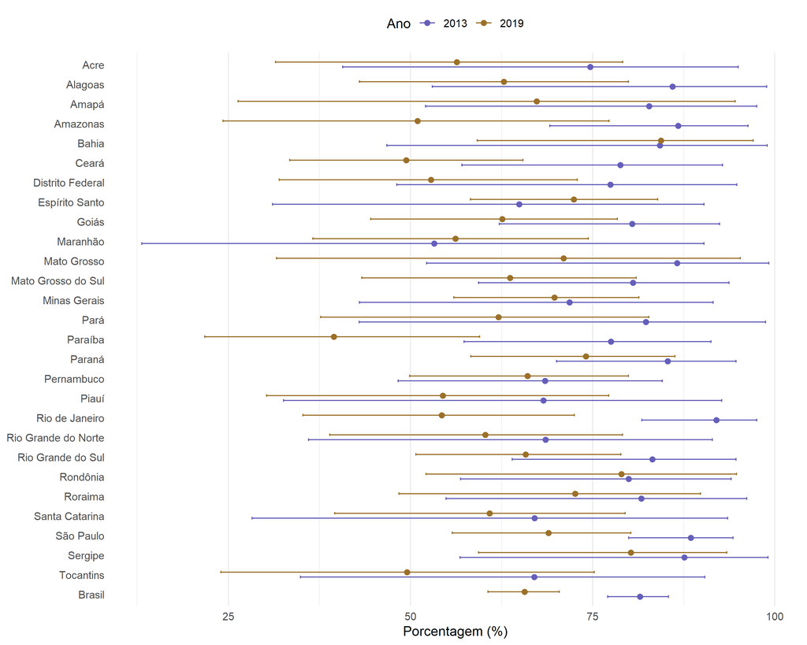

Medicamentos: populações específicas por edição

| UF | Ano | Estimativa [IC 95%] | n válido | Ausentes (%) |
| --- | --- | --- | --- | --- |
| Acre | 2013 | 74,66% [40,69%; 94,95%] | 19 | 0,00 |
| Acre | 2019 | 56,37% [31,46%; 79,11%] | 23 | 0,00 |
| Alagoas | 2013 | 85,95% [53,01%; 98,88%] | 16 | 0,00 |
| Alagoas | 2019 | 62,81% [42,98%; 79,92%] | 46 | 0,00 |
| Amapá | 2013 | 82,76% [52,06%; 97,51%] | 18 | 0,00 |
| Amapá | 2019 | 67,30% [26,36%; 94,55%] | 14 | 0,00 |
| Amazonas | 2013 | 86,72% [69,11%; 96,34%] | 37 | 0,00 |
| Amazonas | 2019 | 50,95% [24,27%; 77,24%] | 26 | 0,00 |
| Bahia | 2013 | 84,22% [46,76%; 98,95%] | 25 | 0,00 |
| Bahia | 2019 | 84,35% [59,16%; 97,02%] | 27 | 0,00 |
| Ceará | 2013 | 78,81% [57,04%; 92,82%] | 34 | 0,00 |
| Ceará | 2019 | 49,40% [33,45%; 65,44%] | 78 | 0,00 |
| Distrito Federal | 2013 | 77,45% [48,12%; 94,77%] | 29 | 0,00 |
| Distrito Federal | 2019 | 52,79% [32,00%; 72,90%] | 34 | 0,00 |
| Espírito Santo | 2013 | 64,90% [31,06%; 90,27%] | 35 | 0,00 |
| Espírito Santo | 2019 | 72,41% [58,25%; 83,91%] | 76 | 0,00 |
| Goiás | 2013 | 80,41% [62,18%; 92,43%] | 43 | 0,00 |
| Goiás | 2019 | 62,59% [44,55%; 78,39%] | 55 | 0,00 |
| Maranhão | 2013 | 53,24% [13,14%; 90,29%] | 15 | 0,00 |
| Maranhão | 2019 | 56,17% [36,62%; 74,41%] | 38 | 0,00 |
| Mato Grosso | 2013 | 86,59% [52,22%; 99,17%] | 16 | 0,00 |
| Mato Grosso | 2019 | 71,01% [31,62%; 95,26%] | 21 | 0,00 |
| Mato Grosso do Sul | 2013 | 80,53% [59,33%; 93,70%] | 30 | 0,00 |
| Mato Grosso do Sul | 2019 | 63,67% [43,33%; 80,97%] | 40 | 0,00 |
| Minas Gerais | 2013 | 71,82% [42,98%; 91,53%] | 68 | 0,00 |
| Minas Gerais | 2019 | 69,75% [55,94%; 81,36%] | 113 | 0,00 |
| Pará | 2013 | 82,30% [42,94%; 98,73%] | 25 | 0,00 |
| Pará | 2019 | 62,09% [37,68%; 82,70%] | 41 | 0,00 |
| Paraíba | 2013 | 77,50% [57,34%; 91,24%] | 27 | 0,00 |
| Paraíba | 2019 | 39,49% [21,76%; 59,50%] | 41 | 0,00 |
| Paraná | 2013 | 85,31% [70,04%; 94,67%] | 61 | 0,00 |
| Paraná | 2019 | 74,05% [58,28%; 86,29%] | 66 | 0,00 |
| Pernambuco | 2013 | 68,46% [48,32%; 84,54%] | 53 | 0,00 |
| Pernambuco | 2019 | 66,07% [49,90%; 79,90%] | 68 | 0,00 |
| Piauí | 2013 | 68,25% [32,59%; 92,72%] | 22 | 0,00 |
| Piauí | 2019 | 54,45% [30,24%; 77,20%] | 39 | 0,00 |
| Rio de Janeiro | 2013 | 91,98% [81,73%; 97,50%] | 51 | 0,00 |
| Rio de Janeiro | 2019 | 54,29% [35,22%; 72,47%] | 61 | 0,00 |
| Rio Grande do Norte | 2013 | 68,53% [36,02%; 91,41%] | 28 | 0,00 |
| Rio Grande do Norte | 2019 | 60,28% [38,93%; 79,11%] | 41 | 0,00 |
| Rio Grande do Sul | 2013 | 83,19% [63,97%; 94,68%] | 68 | 0,00 |
| Rio Grande do Sul | 2019 | 65,81% [50,75%; 78,86%] | 102 | 0,00 |
| Rondônia | 2013 | 79,94% [56,88%; 94,02%] | 25 | 0,00 |
| Rondônia | 2019 | 78,95% [52,16%; 94,73%] | 22 | 0,00 |
| Roraima | 2013 | 81,69% [54,87%; 96,15%] | 24 | 0,00 |
| Roraima | 2019 | 72,60% [48,43%; 89,80%] | 26 | 0,00 |
| Santa Catarina | 2013 | 67,01% [28,27%; 93,54%] | 36 | 0,00 |
| Santa Catarina | 2019 | 60,85% [39,61%; 79,45%] | 53 | 0,00 |
| São Paulo | 2013 | 88,46% [79,92%; 94,26%] | 106 | 0,00 |
| São Paulo | 2019 | 68,96% [55,73%; 80,24%] | 158 | 0,00 |
| Sergipe | 2013 | 87,58% [56,79%; 99,07%] | 22 | 0,00 |
| Sergipe | 2019 | 80,23% [59,33%; 93,40%] | 32 | 0,00 |
| Tocantins | 2013 | 66,97% [34,92%; 90,38%] | 28 | 0,00 |
| Tocantins | 2019 | 49,52% [23,99%; 75,23%] | 27 | 0,00 |
| Brasil | 2013 | 81,50% [77,08%; 85,39%] | 961 | 0,00 |
| Brasil | 2019 | 65,65% [60,63%; 70,43%] | 1368 | 0,00 |

Fonte: cálculos dos autores com microdados oficiais da PNS.

### 5.3.1 Indicadores descontinuados

As apresentações duplicadas de uso geral e após crise foram substituídas pelo indicador condicionado acima. A taxa populacional foi retirada: os fluxos não permitem observar uso entre todos os adultos com diagnóstico. Ausências produzidas pelo questionário não demonstram ausência de tratamento.

# 6 Tabagismo atual

`P050` identifica uso diário ou menos que diário de tabaco. O denominador contém adultos com resposta válida. Os resultados são porcentagens da população adulta.

2013: 14,65% [14,17%; 15,14%]; n = 60202. 2019: 12,59% [12,19%; 12,99%]; n = 88531.

Tabagismo atual

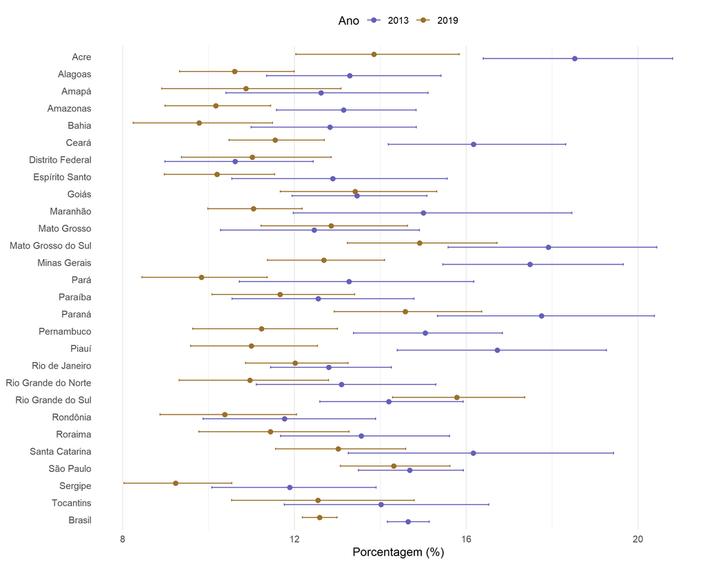

Tabagismo atual

| UF | Ano | Estimativa [IC 95%] | n válido | Ausentes (%) |
| --- | --- | --- | --- | --- |
| Acre | 2013 | 18,53% [16,40%; 20,81%] | 1814 | 0,00 |
| Acre | 2019 | 13,86% [12,04%; 15,84%] | 2283 | 0,00 |
| Alagoas | 2013 | 13,29% [11,35%; 15,42%] | 1748 | 0,00 |
| Alagoas | 2019 | 10,61% [9,33%; 11,99%] | 2898 | 0,00 |
| Amapá | 2013 | 12,62% [10,41%; 15,11%] | 1332 | 0,00 |
| Amapá | 2019 | 10,87% [8,91%; 13,09%] | 1473 | 0,00 |
| Amazonas | 2013 | 13,15% [11,58%; 14,84%] | 2586 | 0,00 |
| Amazonas | 2019 | 10,17% [8,99%; 11,45%] | 3370 | 0,00 |
| Bahia | 2013 | 12,83% [11,00%; 14,84%] | 2641 | 0,00 |
| Bahia | 2019 | 9,78% [8,25%; 11,49%] | 3600 | 0,00 |
| Ceará | 2013 | 16,17% [14,19%; 18,32%] | 2560 | 0,00 |
| Ceará | 2019 | 11,55% [10,48%; 12,70%] | 4141 | 0,00 |
| Distrito Federal | 2013 | 10,62% [8,98%; 12,44%] | 1811 | 0,00 |
| Distrito Federal | 2019 | 11,02% [9,37%; 12,86%] | 2305 | 0,00 |
| Espírito Santo | 2013 | 12,90% [10,54%; 15,56%] | 1724 | 0,00 |
| Espírito Santo | 2019 | 10,20% [8,97%; 11,54%] | 3463 | 0,00 |
| Goiás | 2013 | 13,46% [11,95%; 15,09%] | 2423 | 0,00 |
| Goiás | 2019 | 13,42% [11,67%; 15,32%] | 2648 | 0,00 |
| Maranhão | 2013 | 15,00% [11,97%; 18,46%] | 1774 | 0,00 |
| Maranhão | 2019 | 11,05% [9,98%; 12,18%] | 4889 | 0,00 |
| Mato Grosso | 2013 | 12,46% [10,28%; 14,91%] | 1476 | 0,00 |
| Mato Grosso | 2019 | 12,86% [11,23%; 14,64%] | 2423 | 0,00 |
| Mato Grosso do Sul | 2013 | 17,91% [15,58%; 20,44%] | 1809 | 0,00 |
| Mato Grosso do Sul | 2019 | 14,91% [13,23%; 16,72%] | 2805 | 0,00 |
| Minas Gerais | 2013 | 17,48% [15,46%; 19,66%] | 3779 | 0,00 |
| Minas Gerais | 2019 | 12,69% [11,37%; 14,10%] | 5128 | 0,00 |
| Pará | 2013 | 13,27% [10,72%; 16,18%] | 2004 | 0,00 |
| Pará | 2019 | 9,84% [8,45%; 11,37%] | 3696 | 0,00 |
| Paraíba | 2013 | 12,55% [10,55%; 14,79%] | 1943 | 0,00 |
| Paraíba | 2019 | 11,67% [10,08%; 13,40%] | 3068 | 0,00 |
| Paraná | 2013 | 17,76% [15,33%; 20,39%] | 3012 | 0,00 |
| Paraná | 2019 | 14,58% [12,93%; 16,37%] | 3893 | 0,00 |
| Pernambuco | 2013 | 15,05% [13,38%; 16,85%] | 2591 | 0,00 |
| Pernambuco | 2019 | 11,24% [9,63%; 13,00%] | 3992 | 0,00 |
| Piauí | 2013 | 16,73% [14,40%; 19,27%] | 1804 | 0,00 |
| Piauí | 2019 | 11,00% [9,59%; 12,54%] | 2674 | 0,00 |
| Rio de Janeiro | 2013 | 12,80% [11,45%; 14,26%] | 3486 | 0,00 |
| Rio de Janeiro | 2019 | 12,02% [10,86%; 13,25%] | 4849 | 0,00 |
| Rio Grande do Norte | 2013 | 13,10% [11,11%; 15,29%] | 1691 | 0,00 |
| Rio Grande do Norte | 2019 | 10,97% [9,31%; 12,80%] | 2877 | 0,00 |
| Rio Grande do Sul | 2013 | 14,20% [12,59%; 15,93%] | 2913 | 0,00 |
| Rio Grande do Sul | 2019 | 15,78% [14,29%; 17,37%] | 3707 | 0,00 |
| Rondônia | 2013 | 11,77% [9,87%; 13,89%] | 1694 | 0,00 |
| Rondônia | 2019 | 10,38% [8,87%; 12,05%] | 2108 | 0,00 |
| Roraima | 2013 | 13,56% [11,68%; 15,61%] | 1591 | 0,00 |
| Roraima | 2019 | 11,44% [9,78%; 13,27%] | 2135 | 0,00 |
| Santa Catarina | 2013 | 16,17% [13,26%; 19,43%] | 1623 | 0,00 |
| Santa Catarina | 2019 | 13,02% [11,56%; 14,59%] | 3676 | 0,00 |
| São Paulo | 2013 | 14,68% [13,49%; 15,94%] | 5305 | 0,00 |
| São Paulo | 2019 | 14,31% [13,07%; 15,63%] | 5995 | 0,00 |
| Sergipe | 2013 | 11,89% [10,08%; 13,90%] | 1553 | 0,00 |
| Sergipe | 2019 | 9,23% [8,04%; 10,54%] | 2563 | 0,00 |
| Tocantins | 2013 | 14,02% [11,76%; 16,53%] | 1515 | 0,00 |
| Tocantins | 2019 | 12,55% [10,54%; 14,79%] | 1872 | 0,00 |
| Brasil | 2013 | 14,65% [14,17%; 15,14%] | 60202 | 0,00 |
| Brasil | 2019 | 12,59% [12,19%; 12,99%] | 88531 | 0,00 |

Fonte: cálculos dos autores com microdados oficiais da PNS.

# 7 Contrastes nacionais

Os intervalos abaixo descrevem diretamente a diferença entre edições. Uma diferença compatível com zero não demonstra equivalência. Sem padronização, mudanças de composição etária ou por sexo podem contribuir para o contraste.

Diferenças nacionais: 2019 menos 2013

| Indicador | Diferença (p.p.) | IC 95% |
| --- | --- | --- |
| Crises de asma | -0,65 | [-4,88; 3,58] |
| Diagnóstico de asma | 0,86 | [0,46; 1,26] |
| Tabagismo atual | -2,06 | [-2,69; -1,43] |

Fonte: cálculos dos autores com microdados oficiais da PNS.

# 8 Pagamento por medicamentos

Em 2019, o pagamento é descrito entre usuários elegíveis de medicamentos orais (`Q07707`) e aerossóis (`Q07711`). Os denominadores exigem diagnóstico, crise, prescrição e uso da modalidade. As respostas não informam a quantia paga, o custo total familiar ou gasto catastrófico. Esta seção não estima cobertura do Farmácia Popular.

Pagamento por medicamentos

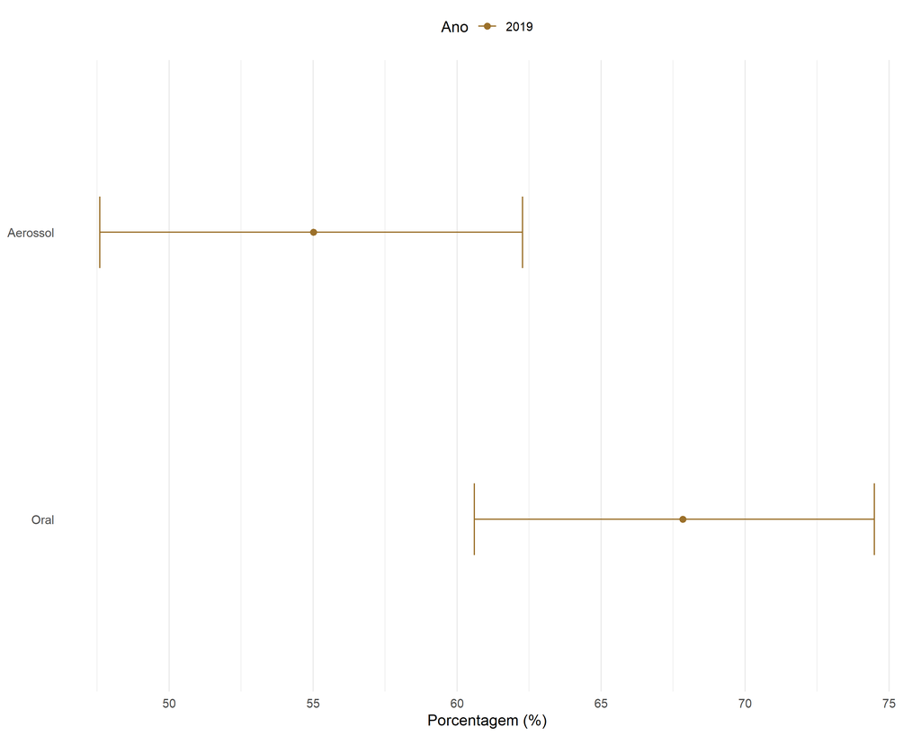

Pagamento por medicamentos

| Indicador | UF | Ano | Estimativa [IC 95%] | n válido | Ausentes (%) |
| --- | --- | --- | --- | --- | --- |
| Aerossol | Brasil | 2019 | 55,02% [47,60%; 62,28%] | 681 | 0,00 |
| Oral | Brasil | 2019 | 67,84% [60,60%; 74,50%] | 796 | 0,00 |

Fonte: cálculos dos autores com microdados oficiais da PNS.

# 9 Atividades habituais e renda

Esta seção descreve adultos, sem restrição a pessoas com asma. Atividades habituais incluem tarefas domésticas, escolares, de lazer e de trabalho; sua restrição não mede exclusivamente absenteísmo laboral.

## 9.1 Restrição por motivo de saúde

`J002` identifica interrupção de atividades nas duas últimas semanas. O denominador contém adultos com resposta válida.

2013: 8,00% [7,63%; 8,40%]; n = 60202. 2019: 8,88% [8,57%; 9,20%]; n = 88531.

Restrição por motivo de saúde

| UF | Ano | Estimativa [IC 95%] | n válido | Ausentes (%) |
| --- | --- | --- | --- | --- |
| Brasil | 2013 | 8,00% [7,63%; 8,40%] | 60202 | 0,00 |
| Brasil | 2019 | 8,88% [8,57%; 9,20%] | 88531 | 0,00 |

Fonte: cálculos dos autores com microdados oficiais da PNS.

## 9.2 Participação das causas entre adultos com restrição

Em 2019, cada causa é estimada entre adultos com restrição e resposta válida a `J00402`. Ignorados são excluídos do denominador e registrados entre as ausências. A classificação usa códigos oficiais.

Participação das causas entre adultos com restrição

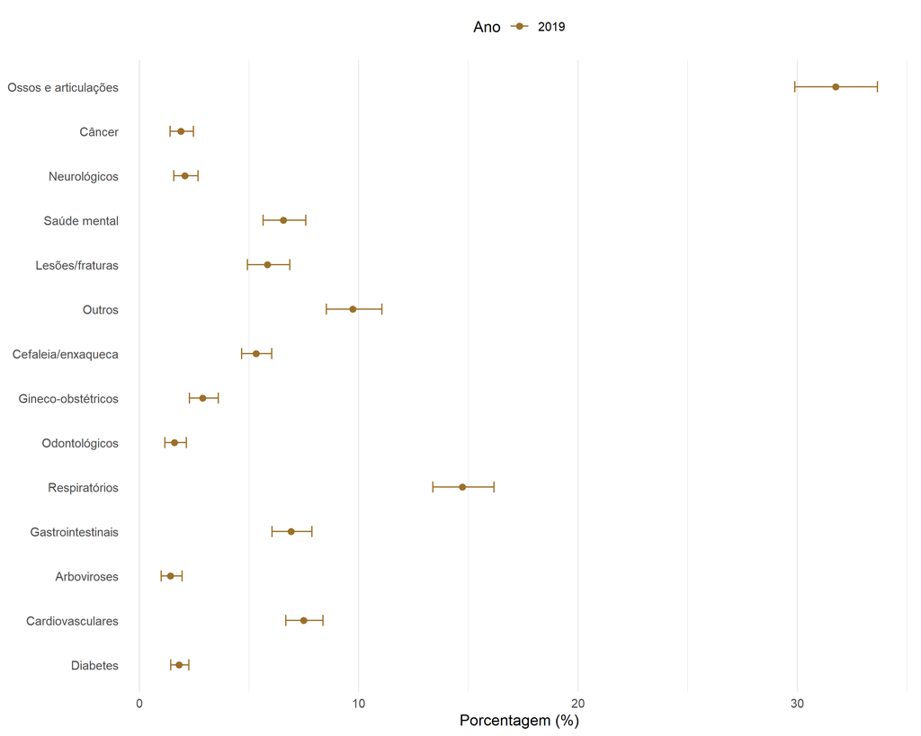

Participação das causas entre adultos com restrição

| Indicador | UF | Ano | Estimativa [IC 95%] | n válido | Ausentes (%) |
| --- | --- | --- | --- | --- | --- |
| Ossos e articulações | Brasil | 2019 | 31,75% [29,89%; 33,65%] | 8693 | 0,00 |
| Câncer | Brasil | 2019 | 1,88% [1,41%; 2,47%] | 8693 | 0,00 |
| Neurológicos | Brasil | 2019 | 2,07% [1,57%; 2,67%] | 8693 | 0,00 |
| Saúde mental | Brasil | 2019 | 6,56% [5,64%; 7,59%] | 8693 | 0,00 |
| Lesões/fraturas | Brasil | 2019 | 5,84% [4,93%; 6,85%] | 8693 | 0,00 |
| Outros | Brasil | 2019 | 9,73% [8,52%; 11,06%] | 8693 | 0,00 |
| Cefaleia/enxaqueca | Brasil | 2019 | 5,31% [4,66%; 6,03%] | 8693 | 0,00 |
| Gineco-obstétricos | Brasil | 2019 | 2,88% [2,28%; 3,60%] | 8693 | 0,00 |
| Odontológicos | Brasil | 2019 | 1,60% [1,17%; 2,14%] | 8693 | 0,00 |
| Respiratórios | Brasil | 2019 | 14,73% [13,38%; 16,16%] | 8693 | 0,00 |
| Gastrointestinais | Brasil | 2019 | 6,91% [6,04%; 7,87%] | 8693 | 0,00 |
| Arboviroses | Brasil | 2019 | 1,42% [1,00%; 1,95%] | 8693 | 0,00 |
| Cardiovasculares | Brasil | 2019 | 7,49% [6,67%; 8,37%] | 8693 | 0,00 |
| Diabetes | Brasil | 2019 | 1,81% [1,43%; 2,26%] | 8693 | 0,00 |

Fonte: cálculos dos autores com microdados oficiais da PNS.

## 9.3 Dias de restrição por causa

As médias de `J003` são condicionadas à presença da causa correspondente. Valores de 1 a 14 dias são válidos; ignorados permanecem ausentes. As médias descrevem intensidade entre pessoas afetadas, sem interpretação de perda anual de produtividade.

Dias de restrição por causa

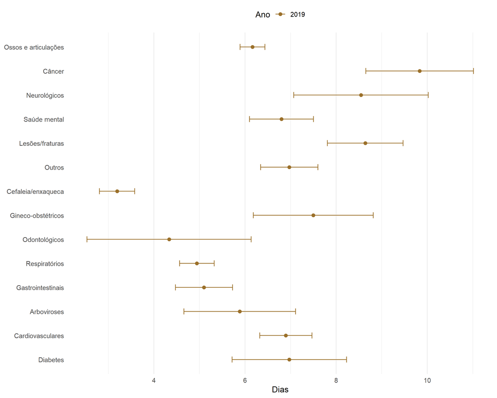

Dias de restrição por causa

| Indicador | UF | Ano | Estimativa [IC 95%] | n válido | Ausentes (%) |
| --- | --- | --- | --- | --- | --- |
| Ossos e articulações | Brasil | 2019 | 6,16 [5,89; 6,44] | 2887 | 0,00 |
| Câncer | Brasil | 2019 | 9,83 [8,65; 11,01] | 139 | 0,00 |
| Neurológicos | Brasil | 2019 | 8,54 [7,07; 10,02] | 160 | 0,00 |
| Saúde mental | Brasil | 2019 | 6,80 [6,10; 7,50] | 524 | 0,00 |
| Lesões/fraturas | Brasil | 2019 | 8,64 [7,81; 9,47] | 484 | 0,00 |
| Outros | Brasil | 2019 | 6,97 [6,34; 7,60] | 796 | 0,00 |
| Cefaleia/enxaqueca | Brasil | 2019 | 3,19 [2,80; 3,58] | 564 | 0,00 |
| Gineco-obstétricos | Brasil | 2019 | 7,50 [6,18; 8,82] | 224 | 0,00 |
| Odontológicos | Brasil | 2019 | 4,33 [2,53; 6,13] | 122 | 0,00 |
| Respiratórios | Brasil | 2019 | 4,94 [4,56; 5,32] | 1190 | 0,00 |
| Gastrointestinais | Brasil | 2019 | 5,10 [4,47; 5,73] | 602 | 0,00 |
| Arboviroses | Brasil | 2019 | 5,88 [4,66; 7,11] | 146 | 0,00 |
| Cardiovasculares | Brasil | 2019 | 6,90 [6,32; 7,47] | 679 | 0,00 |
| Diabetes | Brasil | 2019 | 6,97 [5,72; 8,23] | 176 | 0,00 |

Fonte: cálculos dos autores com microdados oficiais da PNS.

## 9.4 Causas respiratórias: aproximação descritiva

Em 2013, combinam-se `J004 = 10` (resfriado/gripe) e `J004 = 11` (asma/bronquite/pneumonia). Em 2019, `J00402 = 5` inclui também sinusite. A participação é calculada entre adultos com restrição e causa válida. Não há contraste inferencial dessas categorias diferentes nem atribuição exclusiva à asma.

2013: 15,44% [13,58%; 17,45%]; n = 5267. 2019: 14,73% [13,38%; 16,16%]; n = 8693.

Causas respiratórias: aproximação descritiva

| UF | Ano | Estimativa [IC 95%] | n válido | Ausentes (%) |
| --- | --- | --- | --- | --- |
| Brasil | 2013 | 15,44% [13,58%; 17,45%] | 5267 | 0,00 |
| Brasil | 2019 | 14,73% [13,38%; 16,16%] | 8693 | 0,00 |

Fonte: cálculos dos autores com microdados oficiais da PNS.

Dias entre adultos com restrição respiratória

| UF | Ano | Estimativa [IC 95%] | n válido | Ausentes (%) |
| --- | --- | --- | --- | --- |
| Brasil | 2013 | 4,58 [4,09; 5,06] | 738 | 0,00 |
| Brasil | 2019 | 4,94 [4,56; 5,32] | 1190 | 0,00 |

Fonte: cálculos dos autores com microdados oficiais da PNS.

## 9.5 Rendimento individual mensal composto

Mantém-se o somatório de `E01602`, `E01604`, `E01802`, `E01804`, `F001021`, `F007021`, `F008021` e `VDF00102`. Inclui dinheiro e valores estimados de produtos ou mercadorias do trabalho principal e de outros trabalhos, aposentadorias/pensões, pensão alimentícia/doações/mesadas, aluguéis e o agregado de outros rendimentos. Não há filtro por formalização do vínculo.

Zero é atribuído somente quando o questionário comprova ausência da fonte. Recebimento sem quantia válida ou elegibilidade indeterminada deixa o componente desconhecido e impede o cálculo do total. Totais conhecidos iguais a zero são incluídos. Códigos especiais são específicos por variável; o dicionário não identifica `99999999` como ignorado em `VDF00102`.

O deflator oficial leva os valores nominais a julho de 2019; depois o IPCA nacional atualiza para agosto de 2025, sem arredondamento intermediário. A medida está sujeita a cobertura e subdeclaração. Não corresponde a renda domiciliar per capita, renda disponível ou mensuração direta da informalidade. Não será multiplicada por dias de restrição para monetizar produtividade.

2019: 2821,28 [2726,73; 2915,83]; n = 88522.

Rendimento individual mensal composto

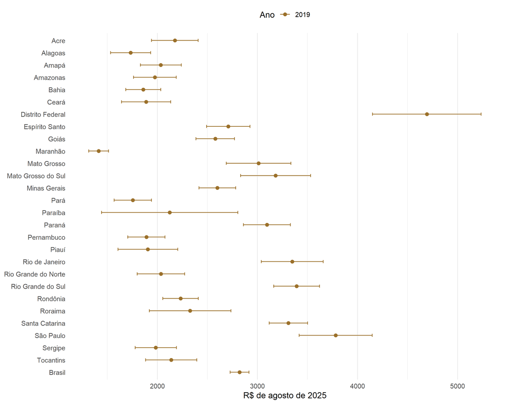

Rendimento individual mensal composto

| UF | Ano | Estimativa [IC 95%] | n válido | Ausentes (%) |
| --- | --- | --- | --- | --- |
| Acre | 2019 | 2174,61 [1940,89; 2408,33] | 2283 | 0,00 |
| Alagoas | 2019 | 1732,62 [1532,16; 1933,09] | 2898 | 0,00 |
| Amapá | 2019 | 2034,59 [1829,98; 2239,20] | 1472 | 0,03 |
| Amazonas | 2019 | 1975,30 [1761,01; 2189,58] | 3370 | 0,00 |
| Bahia | 2019 | 1858,75 [1683,42; 2034,07] | 3600 | 0,00 |
| Ceará | 2019 | 1888,12 [1642,89; 2133,35] | 4140 | 0,03 |
| Distrito Federal | 2019 | 4692,72 [4150,27; 5235,16] | 2305 | 0,00 |
| Espírito Santo | 2019 | 2708,40 [2491,97; 2924,82] | 3461 | 0,03 |
| Goiás | 2019 | 2578,29 [2385,03; 2771,54] | 2648 | 0,00 |
| Maranhão | 2019 | 1413,44 [1314,76; 1512,12] | 4889 | 0,00 |
| Mato Grosso | 2019 | 3011,34 [2688,57; 3334,11] | 2423 | 0,00 |
| Mato Grosso do Sul | 2019 | 3181,43 [2831,09; 3531,76] | 2804 | 0,01 |
| Minas Gerais | 2019 | 2599,36 [2416,34; 2782,39] | 5126 | 0,09 |
| Pará | 2019 | 1755,11 [1567,97; 1942,25] | 3696 | 0,00 |
| Paraíba | 2019 | 2123,70 [1442,52; 2804,88] | 3068 | 0,00 |
| Paraná | 2019 | 3094,71 [2860,73; 3328,69] | 3892 | 0,02 |
| Pernambuco | 2019 | 1890,92 [1704,91; 2076,93] | 3992 | 0,00 |
| Piauí | 2019 | 1905,33 [1607,06; 2203,60] | 2674 | 0,00 |
| Rio de Janeiro | 2019 | 3347,85 [3038,77; 3656,94] | 4849 | 0,00 |
| Rio Grande do Norte | 2019 | 2035,12 [1798,05; 2272,20] | 2877 | 0,00 |
| Rio Grande do Sul | 2019 | 3392,00 [3163,46; 3620,54] | 3706 | 0,04 |
| Rondônia | 2019 | 2232,10 [2054,25; 2409,94] | 2108 | 0,00 |
| Roraima | 2019 | 2327,47 [1919,44; 2735,50] | 2135 | 0,00 |
| Santa Catarina | 2019 | 3309,15 [3117,29; 3501,00] | 3676 | 0,00 |
| São Paulo | 2019 | 3781,15 [3416,32; 4145,98] | 5995 | 0,00 |
| Sergipe | 2019 | 1984,02 [1778,00; 2190,04] | 2563 | 0,00 |
| Tocantins | 2019 | 2138,15 [1882,33; 2393,96] | 1872 | 0,00 |
| Brasil | 2019 | 2821,28 [2726,73; 2915,83] | 88522 | 0,01 |

Fonte: cálculos dos autores com microdados oficiais da PNS.

Totais de renda não calculáveis (%)

| UF | Ano | Estimativa [IC 95%] | n válido | Ausentes (%) |
| --- | --- | --- | --- | --- |
| Brasil | 2019 | 0,01% [0,00%; 0,04%] | 88531 | 0,00 |

Fonte: cálculos dos autores com microdados oficiais da PNS.

Fator de atualização julho de 2019 a agosto de 2025: 1,40192528 .

# 10 Interoperabilidade e reprodução

As tabelas têm identificadores estáveis e campos de elegibilidade, precisão e proveniência. Uma integração futura com dados assistenciais deverá preservar o caráter transversal e o desenho da PNS. O inquérito não fornece trajetórias individuais de cuidado. Princípios de documentação do OMOP/OHDSI podem orientar fontes complementares, respeitando essas diferenças (OHDSI, s.d.).

# 11 Interpretação e limitações

A comparação de diagnóstico, crises e tabagismo depende da equivalência das definições e da aproximação usada para a variância entre edições. Mudanças de composição e acesso ao diagnóstico são explicações possíveis, sem identificação causal. Não se atribuem mudanças ao número de pneumologistas. Medicamentos exigem interpretação específica por edição.

Pagamento não quantifica custos, e causas respiratórias não identificam exclusivamente asma. A análise econômica de 2023–2025 exige outras fontes, regras de atribuição e consideração da defasagem temporal.

Excluir informação desconhecida pode produzir viés se a não resposta estiver associada ao desfecho. A renda composta exige informação suficiente nas oito parcelas, o que pode selecionar pessoas com melhor preenchimento. As saídas registram ausências e precisão para apoiar essa avaliação.

# 12 Validação e arquivos de reprodução

`tools/run_analysis.R` executa a análise completa. As entradas por indicador chamam a mesma implementação. Os resultados passam por uma área intermediária antes da publicação. O manifesto verifica a correspondência entre código, tabelas e relatório. Os testes cobrem recodificação, renda, desenho, estimadores e produtos bilíngues. Comandos e resultados constam do registro de validação.

# 13 Referências

BROWN, Lawrence D.; CAI, T. Tony; DASGUPTA, Anirban. Interval estimation for a binomial proportion. *Statistical Science*, v. 16, n. 2, p. 101-133, 2001. doi:10.1214/ss/1009213286.

DUBE, I.; SILVA, M. E. L. *PNS_2013_2019*. GitHub, 2026. Disponível em: https://github.com/ingodube/PNS_2013_2019. Acesso em: 28 mai. 2026.

GLOBAL ASTHMA NETWORK. *Global Asthma Report 2022*. Auckland, New Zealand: Global Asthma Network, 2022. Disponível em: https://globalasthmareport.org/resources/Global_Asthma_Report_2022.pdf. Acesso em: 19 set. 2025.

IBGE. *IPCA: número-índice, tabela SIDRA 1737*. https://sidra.ibge.gov.br/tabela/1737.

IBGE. *Pesquisa Nacional de Saúde 2013: documentação e questionário*. https://ftp.ibge.gov.br/PNS/2013/Microdados/Documentacao/.

IBGE. *Pesquisa Nacional de Saúde 2019: documentação e questionário*. https://ftp.ibge.gov.br/PNS/2019/Microdados/Documentacao/.

IBGE. *PNSIBGE: documentação de apoio para deflacionamento*. https://ftp.ibge.gov.br/PNS/Documentacao_Geral/PNSIBGE_Deflator.pdf.

KORN, Edward L.; GRAUBARD, Barry I. Confidence intervals for proportions with small expected number of positive counts estimated from survey data. *Survey Methodology*, v. 24, n. 2, p. 193-201, 1998.

LUMLEY, Thomas. *Complex Surveys: A Guide to Analysis Using R*. Hoboken: Wiley, 2010.

MENEZES, A. M. B. et al. Prevalência de diagnóstico médico de asma em adultos brasileiros: Pesquisa Nacional de Saúde, 2013. *Revista Brasileira de Epidemiologia*, São Paulo, v. 18, supl. 2, p. 204-213, 2015.

OHDSI. *ETL Creation Best Practices*. Disponível em: https://www.ohdsi.org/web/wiki/doku.php?id=documentation:etl_best_practices.

OHDSI. *OMOP Common Data Model*. Disponível em: https://ohdsi.github.io/CommonDataModel/.

OHDSI. *Standardized Data: The OMOP Common Data Model*. Disponível em: https://www.ohdsi.org/data-standardization/.

SANTOS, Felipe Moraes dos et al. Tendência da prevalência de asma autorreferida no Brasil de 2003 a 2013 em adultos e fatores associados à prevalência. *Jornal Brasileiro de Pneumologia*, v. 44, n. 6, p. 491-497, 2018. doi:10.1590/S1806-37562017000000328.

SEVERE ASTHMA. *Non-Pharmacological Interventions for Asthma*. Disponível em: https://www.severeasthma.org.au/non-pharmacological-interventions-asthma/. Acesso em: 19 set. 2025.

SOUZA-JÚNIOR, Paulo Roberto Borges de et al. Desenho da amostra da Pesquisa Nacional de Saúde 2013. *Epidemiologia e Serviços de Saúde*, v. 24, p. 207-216, 2015.

TO, T. et al. Global asthma prevalence in adults: findings from the cross-sectional world health survey. *BMC Public Health*, v. 12, art. 204, 2012. doi:10.1186/1471-2458-12-204.

# Declaração de uso de inteligência artificial

Foi utilizada inteligência artificial para auxiliar a implementação, a revisão da redação e a tradução para o inglês. A skill humanizer orientou a revisão editorial, preservando definições, referências, números e limitações. A autoria e a responsabilidade pela interpretação científica permanecem com os autores.